```python
import seaborn as sns
import matplotlib.pyplot as plt
import pandas as pd
from scipy import stats
import numpy as np
%matplotlib inline
sns.set_style('darkgrid')
%matplotlib inline
import warnings
warnings.filterwarnings("ignore")
```

# PART - A

### 1. Data Understanding: A. Read all the 3 CSV files as DataFrame and store them into 3 separate variables

```python
normal = pd.read_csv('Normal.csv')
type_h = pd.read_csv('Type_H.csv')
type_s = pd.read_csv('Type_S.csv')
```

```python
normal.head()
```

|  | P_incidence | P_tilt | L_angle | S_slope | P_radius | S_Degree | Class |
| --- | --- | --- | --- | --- | --- | --- | --- |
| 0 | 38.505273 | 16.964297 | 35.112814 | 21.540976 | 127.632875 | 7.986683 | Normal |
| 1 | 54.920858 | 18.968430 | 51.601455 | 35.952428 | 125.846646 | 2.001642 | Normal |
| 2 | 44.362490 | 8.945435 | 46.902096 | 35.417055 | 129.220682 | 4.994195 | Normal |
| 3 | 48.318931 | 17.452121 | 48.000000 | 30.866809 | 128.980308 | -0.910941 | Normal |
| 4 | 45.701789 | 10.659859 | 42.577846 | 35.041929 | 130.178314 | -3.388910 | Normal |

```python
type_h.head()
```

|  | P_incidence | P_tilt | L_angle | S_slope | P_radius | S_Degree | Class |
| --- | --- | --- | --- | --- | --- | --- | --- |
| 0 | 63.027817 | 22.552586 | 39.609117 | 40.475232 | 98.672917 | -0.254400 | Type_H |
| 1 | 39.056951 | 10.060991 | 25.015378 | 28.995960 | 114.405425 | 4.564259 | Type_H |
| 2 | 68.832021 | 22.218482 | 50.092194 | 46.613539 | 105.985135 | -3.530317 | Type_H |
| 3 | 69.297008 | 24.652878 | 44.311238 | 44.644130 | 101.868495 | 11.211523 | Type_H |
| 4 | 49.712859 | 9.652075 | 28.317406 | 40.060784 | 108.168725 | 7.918501 | Type_H |

```python
type_s.head()
```

|  | P_incidence | P_tilt | L_angle | S_slope | P_radius | S_Degree | Class |
| --- | --- | --- | --- | --- | --- | --- | --- |
| 0 | 74.377678 | 32.053104 | 78.772013 | 42.324573 | 143.560690 | 56.125906 | Type_S |
| 1 | 89.680567 | 32.704435 | 83.130732 | 56.976132 | 129.955476 | 92.027277 | Type_S |
| 2 | 44.529051 | 9.433234 | 52.000000 | 35.095817 | 134.711772 | 29.106575 | Type_S |
| 3 | 77.690577 | 21.380645 | 64.429442 | 56.309932 | 114.818751 | 26.931841 | Type_S |
| 4 | 76.147212 | 21.936186 | 82.961502 | 54.211027 | 123.932010 | 10.431972 | Type_S |

### B. Print Shape and columns of all the 3 DataFrames.

```python
normal_shape = normal.shape
type_h_shape = type_h.shape
type_s_shape = type_s.shape
print(f'normal dataset: {normal_shape} ; has rows: {normal_shape[0]} ; has columns: {normal_shape[1]}')
print(f'type_h dataset: {type_h_shape}  ; has rows: {type_h_shape[0]}  ; has columns: {type_h_shape[1]}')
print(f'type_s dataset: {type_s_shape}  ; has rows: {type_s_shape[0]}  ; has columns: {type_s_shape[1]}')
```

```
normal dataset: (100, 7) ; has rows: 100 ; has columns: 7
type_h dataset: (60, 7)  ; has rows: 60  ; has columns: 7
type_s dataset: (150, 7)  ; has rows: 150  ; has columns: 7
```

### C. Compare Column names of all the 3 DataFrames and clearly write observations.

```python
normal_col = np.asarray(normal.columns)
type_h_col = np.asarray(type_h.columns)
type_s_col = np.asarray(type_s.columns)
print(f'columns within normal dataset: {normal_col}')
print(f'columns within type_h dataset: {type_h_col}')
print(f'columns within type_s dataset: {type_s_col}')
print("Logical comparision of the columns ",np.logical_and((normal_col == type_h_col).all(), (type_h_col == type_s_col).all()))
```

```
columns within normal dataset: ['P_incidence' 'P_tilt' 'L_angle' 'S_slope' 'P_radius' 'S_Degree' 'Class']
columns within type_h dataset: ['P_incidence' 'P_tilt' 'L_angle' 'S_slope' 'P_radius' 'S_Degree' 'Class']
columns within type_s dataset: ['P_incidence' 'P_tilt' 'L_angle' 'S_slope' 'P_radius' 'S_Degree' 'Class']
Logical comparision of the columns  True
```

Observations:

In three datasets, all have same names for columns and equal number of columns

### D. Print DataTypes of all the 3 DataFrames.

```python
normal.dtypes
```

```
P_incidence    float64
P_tilt         float64
L_angle        float64
S_slope        float64
P_radius       float64
S_Degree       float64
Class           object
dtype: object
```

```python
type_h.dtypes
```

```
P_incidence    float64
P_tilt         float64
L_angle        float64
S_slope        float64
P_radius       float64
S_Degree       float64
Class           object
dtype: object
```

```python
type_s.dtypes
```

```
P_incidence    float64
P_tilt         float64
L_angle        float64
S_slope        float64
P_radius       float64
S_Degree       float64
Class           object
dtype: object
```

### E. Observe and share variation in ‘Class’ feature of all the 3 DataFrames.

```python
normal.Class.value_counts()
```

```
Normal    73
Nrmal     27
Name: Class, dtype: int64
```

```python
type_h.Class.value_counts()
```

```
Type_H    37
type_h    23
Name: Class, dtype: int64
```

```python
type_s.Class.value_counts()
```

```
Type_S    133
tp_s       17
Name: Class, dtype: int64
```

```python
print("Unique class values in normal",normal.Class.unique())
print("Unique class values in type_h",type_h.Class.unique())
print("Unique class values in type_s",type_s.Class.unique())
```

```
Unique class values in normal ['Normal' 'Nrmal']
Unique class values in type_h ['Type_H' 'type_h']
Unique class values in type_s ['Type_S' 'tp_s']
```

Observations:

There are a few variations in the 'Class' columns of all 3 datasets so we intend to unify them. Some minor changes to be done in the following dataset

1. convert 'Nrmal' to 'Normal' in teh dataframe of normal.csv
2. convert 'type_h' to 'Type_H' in teh dataframe of type_h.csv
3. convert 'tp_s' to 'Type_S' in teh dataframe of type_s.csv

### 2. Data Preparation and Exploration: A. Unify all the variations in ‘Class’ feature for all the 3 DataFrames.

```python
normal.loc[normal.Class == 'Nrmal', 'Class'] = 'Normal'
print(normal.Class.unique())
type_h.loc[type_h.Class == 'type_h', 'Class'] = 'Type_H'
print(type_h.Class.unique())
type_s.loc[type_s.Class == 'tp_s', 'Class'] = 'Type_S'
print(type_s.Class.unique())
```

```
['Normal']
['Type_H']
['Type_S']
```

### B. Combine all the 3 DataFrames to form a single DataFrame

```python
final = pd.concat([normal, type_h, type_s], ignore_index= True)
```

```python
final.dtypes
```

```
P_incidence    float64
P_tilt         float64
L_angle        float64
S_slope        float64
P_radius       float64
S_Degree       float64
Class           object
dtype: object
```

```python
final_shape = final.shape
print(f'final dataset: {final_shape} ;has rows: {final_shape[0]} ; has columns: {final_shape[1]}')
```

```
final dataset: (310, 7) ;has rows: 310 ; has columns: 7
```

```python
final.Class.value_counts()
```

```
Type_S    150
Normal    100
Type_H     60
Name: Class, dtype: int64
```

```python
final.dtypes
```

```
P_incidence    float64
P_tilt         float64
L_angle        float64
S_slope        float64
P_radius       float64
S_Degree       float64
Class           object
dtype: object
```

### C. Print 5 random samples of this DataFrame

```python
final.sample(n=5)
```

|  | P_incidence | P_tilt | L_angle | S_slope | P_radius | S_Degree | Class |
| --- | --- | --- | --- | --- | --- | --- | --- |
| 135 | 31.484218 | 7.826221 | 24.284818 | 23.657997 | 113.833145 | 4.393080 | Type_H |
| 168 | 72.076278 | 18.946176 | 51.000000 | 53.130102 | 114.213013 | 1.010041 | Type_S |
| 177 | 58.782548 | 7.667044 | 53.338941 | 51.115504 | 98.501157 | 51.584125 | Type_S |
| 137 | 35.703458 | 19.443253 | 20.700000 | 16.260205 | 137.540613 | -0.263490 | Type_H |
| 9 | 64.311867 | 26.328369 | 50.958964 | 37.983498 | 106.177751 | 3.118221 | Normal |

```python
final.head()
```

|  | P_incidence | P_tilt | L_angle | S_slope | P_radius | S_Degree | Class |
| --- | --- | --- | --- | --- | --- | --- | --- |
| 0 | 38.505273 | 16.964297 | 35.112814 | 21.540976 | 127.632875 | 7.986683 | Normal |
| 1 | 54.920858 | 18.968430 | 51.601455 | 35.952428 | 125.846646 | 2.001642 | Normal |
| 2 | 44.362490 | 8.945435 | 46.902096 | 35.417055 | 129.220682 | 4.994195 | Normal |
| 3 | 48.318931 | 17.452121 | 48.000000 | 30.866809 | 128.980308 | -0.910941 | Normal |
| 4 | 45.701789 | 10.659859 | 42.577846 | 35.041929 | 130.178314 | -3.388910 | Normal |

### D. Print Feature-wise percentage of Null values.

```python
final.isna().sum()
```

```
P_incidence    0
P_tilt         0
L_angle        0
S_slope        0
P_radius       0
S_Degree       0
Class          0
dtype: int64
```

```python
perc = final.isnull().sum() * 100 / len(final)
miss = pd.DataFrame({'Percentages of missing Values': perc})
miss
```

|  | Percentages of missing Values |
| --- | --- |
| P_incidence | 0.0 |
| P_tilt | 0.0 |
| L_angle | 0.0 |
| S_slope | 0.0 |
| P_radius | 0.0 |
| S_Degree | 0.0 |
| Class | 0.0 |

Observation:

Since there is no column/ feature having null values in the final dataset. The percentage of values tahat are null will be zero.

### E. Check 5-point summary of the new DataFrame.

```python
final.describe()
```

|  | P_incidence | P_tilt | L_angle | S_slope | P_radius | S_Degree |
| --- | --- | --- | --- | --- | --- | --- |
| count | 310.000000 | 310.000000 | 310.000000 | 310.000000 | 310.000000 | 310.000000 |
| mean | 60.496653 | 17.542822 | 51.930930 | 42.953831 | 117.920655 | 26.296694 |
| std | 17.236520 | 10.008330 | 18.554064 | 13.423102 | 13.317377 | 37.559027 |
| min | 26.147921 | -6.554948 | 14.000000 | 13.366931 | 70.082575 | -11.058179 |
| 25% | 46.430294 | 10.667069 | 37.000000 | 33.347122 | 110.709196 | 1.603727 |
| 50% | 58.691038 | 16.357689 | 49.562398 | 42.404912 | 118.268178 | 11.767934 |
| 75% | 72.877696 | 22.120395 | 63.000000 | 52.695888 | 125.467674 | 41.287352 |
| max | 129.834041 | 49.431864 | 125.742385 | 121.429566 | 163.071041 | 418.543082 |

```python
final.describe().T
```

|  | count | mean | std | min | 25% | 50% | 75% | max |
| --- | --- | --- | --- | --- | --- | --- | --- | --- |
| P_incidence | 310.0 | 60.496653 | 17.236520 | 26.147921 | 46.430294 | 58.691038 | 72.877696 | 129.834041 |
| P_tilt | 310.0 | 17.542822 | 10.008330 | -6.554948 | 10.667069 | 16.357689 | 22.120395 | 49.431864 |
| L_angle | 310.0 | 51.930930 | 18.554064 | 14.000000 | 37.000000 | 49.562398 | 63.000000 | 125.742385 |
| S_slope | 310.0 | 42.953831 | 13.423102 | 13.366931 | 33.347122 | 42.404912 | 52.695888 | 121.429566 |
| P_radius | 310.0 | 117.920655 | 13.317377 | 70.082575 | 110.709196 | 118.268178 | 125.467674 | 163.071041 |
| S_Degree | 310.0 | 26.296694 | 37.559027 | -11.058179 | 1.603727 | 11.767934 | 41.287352 | 418.543082 |

Observations

### 3. Data Analysis: A. Visualize a heatmap to understand correlation between all features

```python
final.corr()
```

|  | P_incidence | P_tilt | L_angle | S_slope | P_radius | S_Degree |
| --- | --- | --- | --- | --- | --- | --- |
| P_incidence | 1.000000 | 0.629199 | 0.717282 | 0.814960 | -0.247467 | 0.638743 |
| P_tilt | 0.629199 | 1.000000 | 0.432764 | 0.062345 | 0.032668 | 0.397862 |
| L_angle | 0.717282 | 0.432764 | 1.000000 | 0.598387 | -0.080344 | 0.533667 |
| S_slope | 0.814960 | 0.062345 | 0.598387 | 1.000000 | -0.342128 | 0.523557 |
| P_radius | -0.247467 | 0.032668 | -0.080344 | -0.342128 | 1.000000 | -0.026065 |
| S_Degree | 0.638743 | 0.397862 | 0.533667 | 0.523557 | -0.026065 | 1.000000 |

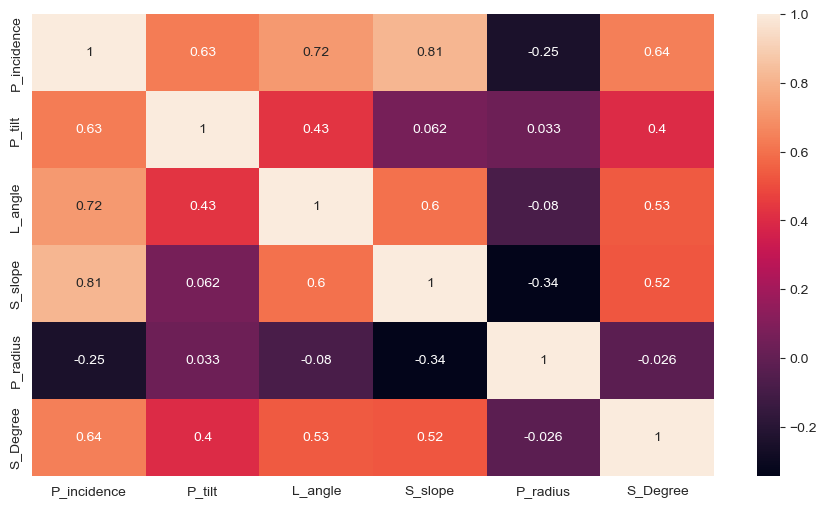

```python
plt.figure(figsize= (11,6))
sns.heatmap(final.corr(), annot=True);
plt.show();
```

### B. Share insights on correlation.

#### A. Features having stronger correlation with correlation value.

1. Features P_incidence and S_slope have the strongest correlation of 0.81
2. Features P_incidence & L_angle have a good correlation of 0.72
3. Features P_incidence & S_Degreehave a better correlation of 0.64

#### B. Features having weaker correlation with correlation value.

1. features P_radius and S_Degree have the weakest correlation of -0.026 which is a negative correlation 2.features P_radius and P_tilt have weaker correlation 0.033 3.features P_radius and L_angle have a bad correlation of -0.08 which is a negative correlation

### C. Visualize a pairplot with 3 classes distinguished by colors and share insights.

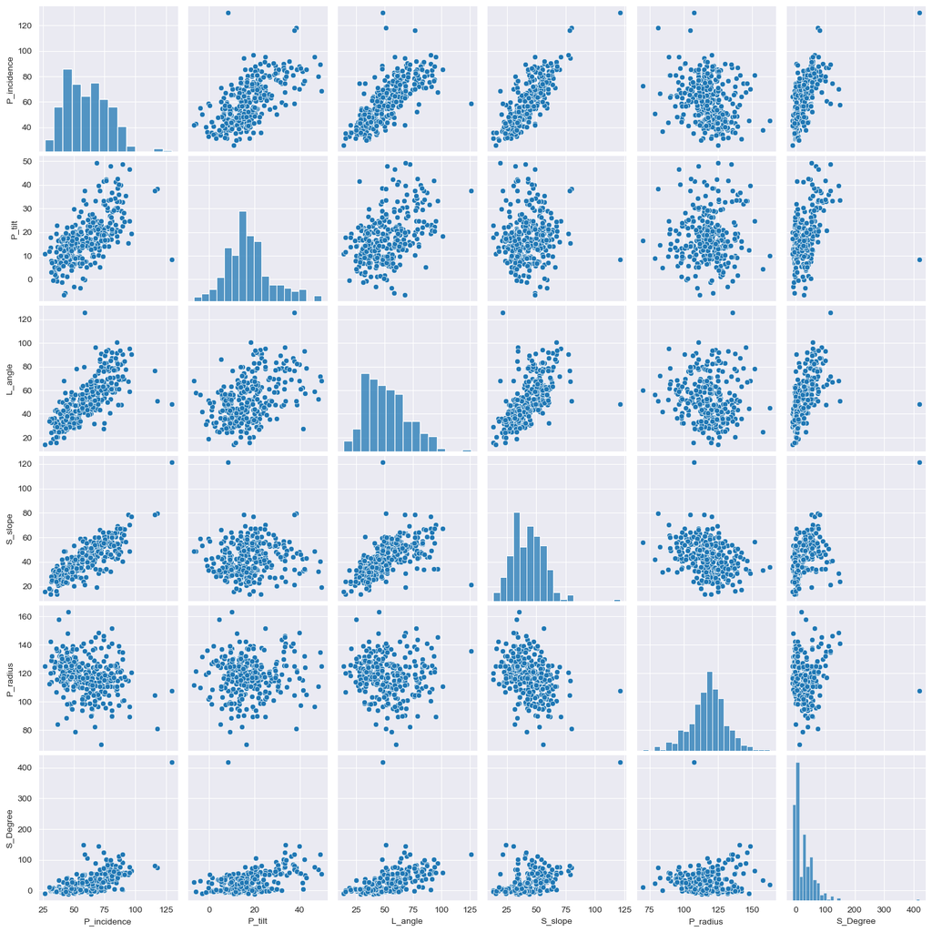

```python
plt.figure(figsize=(10,5))
sns.pairplot(final);
```

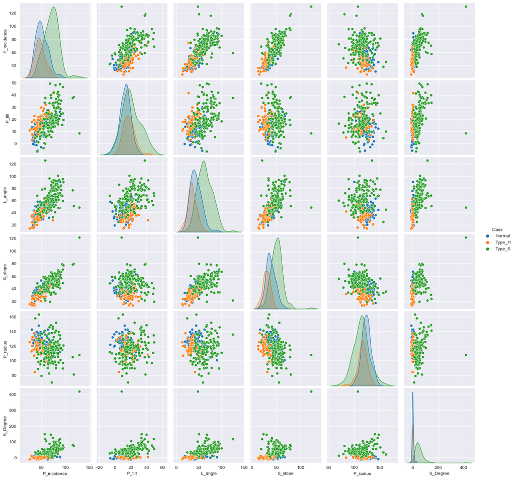

```python
sns.pairplot(final,hue='Class')
```

Observations: The 3 classes that we see here are Normal, Type_H and Type_S

### D. Visualize a jointplot for ‘P_incidence’ and ‘S_slope’ and share insights.

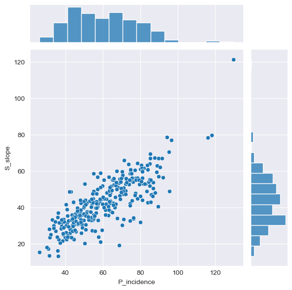

```python
# without hue
sns.jointplot(x='P_incidence', y = 'S_slope',data=final)
```

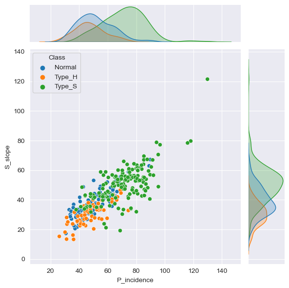

```python
sns.jointplot(x='P_incidence', y = 'S_slope',data=final, hue='Class')
```

Observations

1. Features S_slope & P_incidence have positive correlation indicating taht have an incresing relationship, as 1 increses teh other alos increases
2. There is overlapping in the different classes majority of the data
3. In comparision with the other classes. Types_S has more data entries

### E. Visualize a boxplot to check distribution of the features and share insights.

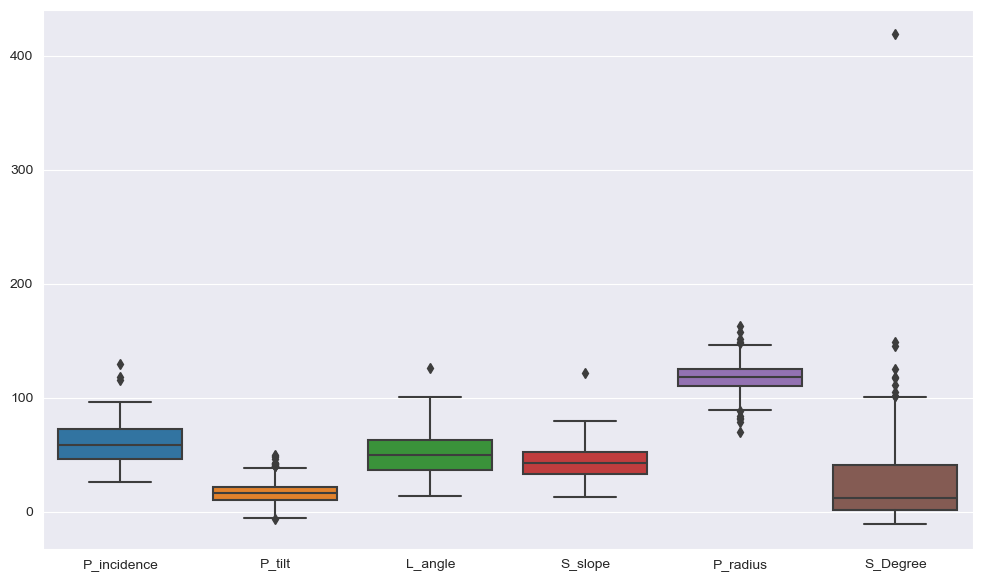

```python
plt.figure(figsize=(12,7))
sns.boxplot(data= final);
```

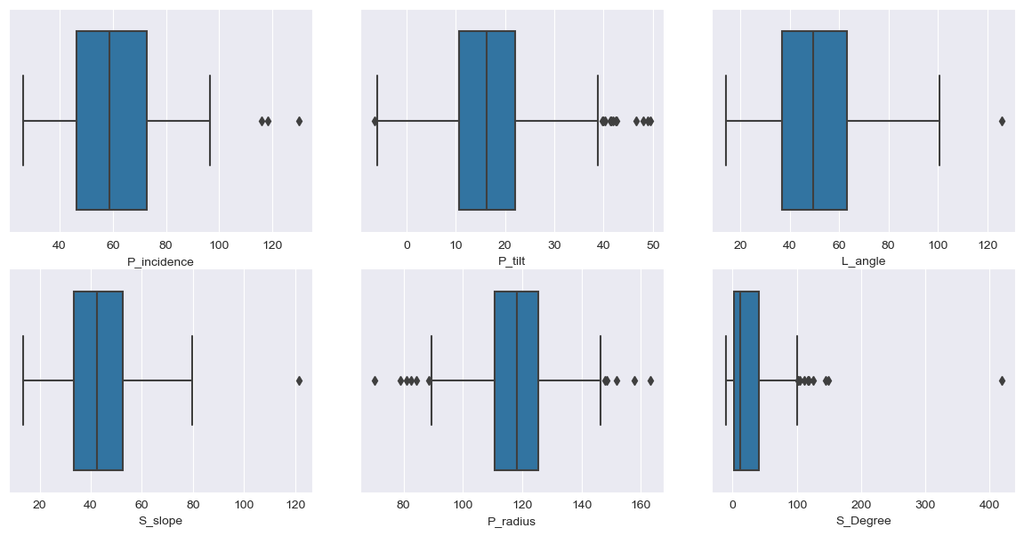

```python
fig, ax = plt.subplots(2, 3)
fig.set_figheight(6)
fig.set_figwidth(12)
fig.tight_layout()
sns.boxplot(x=final['P_incidence'],ax=ax[0][0]);
sns.boxplot(x=final['P_tilt'],ax=ax[0][1]);
sns.boxplot(x=final['L_angle'],ax=ax[0][2]);
sns.boxplot(x=final['S_slope'],ax=ax[1][0]);
sns.boxplot(x=final['P_radius'],ax=ax[1][1]);
sns.boxplot(x=final['S_Degree'],ax=ax[1][2]);
```

Observations

- According to the plots, we see that all the features have outliers
- Features L_angle, S_slope have the least outliers (only 1)
- Feature P_radius has outliers on both the sides.

## 4. Model Building

#### Before implementing the KNN Model we would want to

```python
from sklearn.model_selection import train_test_split
from sklearn.neighbors import KNeighborsClassifier
from sklearn.preprocessing import LabelEncoder
from sklearn.model_selection import train_test_split
from sklearn import metrics
from scipy.stats import zscore
from sklearn.metrics import accuracy_score, recall_score, precision_score, confusion_matrix, classification_report
```

### A. Split data into X and Y.

```python
le = LabelEncoder()
final['Class'] = le.fit_transform(final['Class'])
X=final.drop(columns='Class')
y=final['Class']
X = X.apply(zscore)
```

### B. Split data into train and test with 80:20 proportion

```python
X_train, X_test, y_train, y_test = train_test_split(X, y, test_size=0.20, random_state=7)
print(X_train.shape)
print(y_train.shape)
print(X_test.shape)
print(y_test.shape)
```

```
(248, 6)
(248,)
(62, 6)
(62,)
```

### C. Train a Supervised Learning Classification base model using KNN classifier.

```python
KNN = KNeighborsClassifier(n_neighbors= 1 , weights = 'distance' )
KNN.fit(X_train, y_train)
y_pred = KNN.predict(X_test)
```

### D. Print all the possible performance metrics for both train and test data.

```python
print('Accuracy -', accuracy_score(y_test, y_pred) )
print('Recall -', recall_score(y_test, y_pred, average= 'weighted') )
print('Precision -', precision_score(y_test, y_pred, average= 'weighted'))
```

```
Accuracy - 0.7903225806451613
Recall - 0.7903225806451613
Precision - 0.7938364055299539
```

```python
pred = KNN.predict(X_test)
KNN.score(X_test, y_test)
```

```
0.7903225806451613
```

```python
conf_mat=metrics.confusion_matrix(y_test, pred)
df_conf_mat = pd.DataFrame(
                conf_mat,
                index = [y for y in ["Normal","Type_H","Type_S"]],
                columns = [x for x in ["Predict Normal","Predict Type_H", "Predict Type_S"]])
```

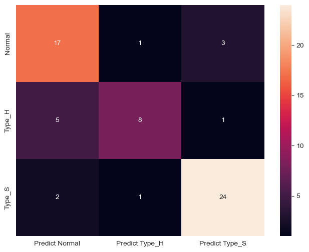

```python
plt.figure(figsize = (8,6))
sns.heatmap(df_conf_mat, annot=True)
```

Observations

```python
print("classification  Matrix:\n", classification_report(y_test,y_pred))
```

```
classification  Matrix:
               precision    recall  f1-score   support

           0       0.71      0.81      0.76        21
           1       0.80      0.57      0.67        14
           2       0.86      0.89      0.87        27

    accuracy                           0.79        62
   macro avg       0.79      0.76      0.76        62
weighted avg       0.79      0.79      0.79        62
```

## 5. Performance Improvement:

### A. Experiment with various parameters to improve performance of the base model.

```
The optimal number of neighbours is 11
```

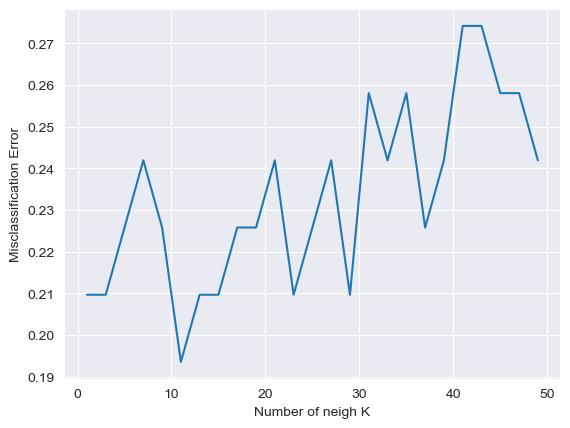

```python
myList = list(range(1,50))
neigh = list(filter(lambda x: x % 2 != 0, myList))
ac_scores = []
for k in neigh:
    knn = KNeighborsClassifier(n_neighbors=k)
    knn.fit(X_train, y_train)
    y_pred = knn.predict(X_test)
    scores = accuracy_score(y_test, y_pred)
    ac_scores.append(scores)
MSE = [1 - x for x in ac_scores]
optimal_k = neigh[MSE.index(min(MSE))]
print("The optimal number of neighbours is %d" % optimal_k)

import matplotlib.pyplot as plt
plt.plot(neigh, MSE)
plt.xlabel('Number of neigh K')
plt.ylabel('Misclassification Error')
plt.show()
```

Observations

It can be inferres from teh eblow method above that the optimal K value for this dataset is 11

```
Accuracy for K=11: 0.8064516129032258
Recall for K=11: 0.8064516129032258
Precision for K=11: 0.811766862170088
```

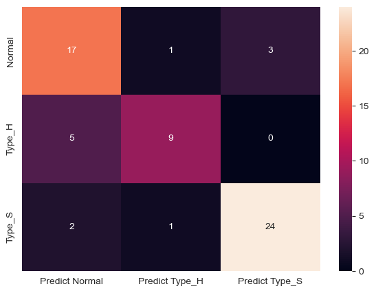

```python
knn_new_best = KNeighborsClassifier(n_neighbors= 11 , weights = 'distance' )
knn_new_best.fit(X_train, y_train)
y_pred = knn_new_best.predict(X_test)
print('Accuracy for K=11:', accuracy_score(y_test, y_pred) )
print('Recall for K=11:', recall_score(y_test, y_pred, average= 'weighted') )
print('Precision for K=11:', precision_score(y_test, y_pred, average= 'weighted'))
predicted_labels = knn_new_best.predict(X_test)
knn_new_best.score(X_test, y_test)
cm=metrics.confusion_matrix(y_test, predicted_labels, labels=[0,1,2])
df_cm = pd.DataFrame(cm, index = [i for i in ["Normal","Type_H","Type_S"]],
                  columns = [i for i in ["Predict Normal","Predict Type_H", "Predict Type_S"]])

plt.figure(figsize = (7,5))
sns.heatmap(df_cm, annot=True)
```

```python
print( classification_report(y_test,predicted_labels))
```

```
              precision    recall  f1-score   support

           0       0.71      0.81      0.76        21
           1       0.82      0.64      0.72        14
           2       0.89      0.89      0.89        27

    accuracy                           0.81        62
   macro avg       0.81      0.78      0.79        62
weighted avg       0.81      0.81      0.81        62
```

### B. Clearly showcase improvement in performance achieved.

Observations:

- Accuracy & Recall: For the Basic Model (k = 1) it is 0.7903 and the Final Model ( k = 11)it is 0.8064 so an improvement of 2.03 %
- Precision: For the Basic Model (k = 1) it is 0.7938 and the Final Model ( k = 11) it is 0.8117 so an improvement of 2.25 %

### C. Clearly state which parameters contributed most to improve model performance.

- In KNN Model K is the only hyperparameter
- Choosing K = 11 as we see fro the elbow plot produces to better results.

# PART - B

## 1. Data Understanding and Preparation: A. Read both the Datasets ‘Data1’ and ‘Data 2’ as DataFrame and store them into two separate variables

```python
df_1 = pd.read_csv('Data1.csv')
df_2 = pd.read_csv('Data2.csv')
```

### B. Print shape and Column Names and DataTypes of both the Dataframes.

```python
df_1_shape = df_1.shape
df_2_shape = df_2.shape
print(f'data1 dataset: {df_1_shape} ; has rows: {df_1_shape[0]} ; has columns: {df_1_shape[1]}')
print(f'data2 dataset: {df_2_shape} ; has rows: {df_2_shape[0]} ; has columns: {df_2_shape[1]}')
```

```
data1 dataset: (5000, 8) ; has rows: 5000 ; has columns: 8
data2 dataset: (5000, 7) ; has rows: 5000 ; has columns: 7
```

```python
df_1.dtypes
```

```
ID                       int64
Age                      int64
CustomerSince            int64
HighestSpend             int64
ZipCode                  int64
HiddenScore              int64
MonthlyAverageSpend    float64
Level                    int64
dtype: object
```

```python
df_2.dtypes
```

```
ID                       int64
Mortgage                 int64
Security                 int64
FixedDepositAccount      int64
InternetBanking          int64
CreditCard               int64
LoanOnCard             float64
dtype: object
```

```python
df_1.head()
```

|  | ID | Age | CustomerSince | HighestSpend | ZipCode | HiddenScore | MonthlyAverageSpend | Level |
| --- | --- | --- | --- | --- | --- | --- | --- | --- |
| 0 | 1 | 25 | 1 | 49 | 91107 | 4 | 1.6 | 1 |
| 1 | 2 | 45 | 19 | 34 | 90089 | 3 | 1.5 | 1 |
| 2 | 3 | 39 | 15 | 11 | 94720 | 1 | 1.0 | 1 |
| 3 | 4 | 35 | 9 | 100 | 94112 | 1 | 2.7 | 2 |
| 4 | 5 | 35 | 8 | 45 | 91330 | 4 | 1.0 | 2 |

```python
df_2.head()
```

|  | ID | Mortgage | Security | FixedDepositAccount | InternetBanking | CreditCard | LoanOnCard |
| --- | --- | --- | --- | --- | --- | --- | --- |
| 0 | 1 | 0 | 1 | 0 | 0 | 0 | NaN |
| 1 | 2 | 0 | 1 | 0 | 0 | 0 | NaN |
| 2 | 3 | 0 | 0 | 0 | 0 | 0 | NaN |
| 3 | 4 | 0 | 0 | 0 | 0 | 0 | NaN |
| 4 | 5 | 0 | 0 | 0 | 0 | 1 | NaN |

### C. Merge both the Dataframes on ‘ID’ feature to form a single DataFrame

```python
df=df_1.merge(df_2,left_on='ID',right_on='ID')
df.shape
```

```
(5000, 14)
```

```python
# sample data
df.head()
```

|  | ID | Age | CustomerSince | HighestSpend | ZipCode | HiddenScore | MonthlyAverageSpend | Level | Mortgage | Security | FixedDepositAccount | InternetBanking | CreditCard | LoanOnCard |
| --- | --- | --- | --- | --- | --- | --- | --- | --- | --- | --- | --- | --- | --- | --- |
| 0 | 1 | 25 | 1 | 49 | 91107 | 4 | 1.6 | 1 | 0 | 1 | 0 | 0 | 0 | NaN |
| 1 | 2 | 45 | 19 | 34 | 90089 | 3 | 1.5 | 1 | 0 | 1 | 0 | 0 | 0 | NaN |
| 2 | 3 | 39 | 15 | 11 | 94720 | 1 | 1.0 | 1 | 0 | 0 | 0 | 0 | 0 | NaN |
| 3 | 4 | 35 | 9 | 100 | 94112 | 1 | 2.7 | 2 | 0 | 0 | 0 | 0 | 0 | NaN |
| 4 | 5 | 35 | 8 | 45 | 91330 | 4 | 1.0 | 2 | 0 | 0 | 0 | 0 | 1 | NaN |

```python
df.dtypes
```

```
ID                       int64
Age                      int64
CustomerSince            int64
HighestSpend             int64
ZipCode                  int64
HiddenScore              int64
MonthlyAverageSpend    float64
Level                    int64
Mortgage                 int64
Security                 int64
FixedDepositAccount      int64
InternetBanking          int64
CreditCard               int64
LoanOnCard             float64
dtype: object
```

### D. Change Datatype of below features to ‘Object’

```python
col=['HiddenScore','Level','Security','FixedDepositAccount', 'InternetBanking', 'CreditCard']
for i in col:
    df[i]=df[i].astype('category')
```

```python
df.dtypes
```

```
ID                        int64
Age                       int64
CustomerSince             int64
HighestSpend              int64
ZipCode                   int64
HiddenScore            category
MonthlyAverageSpend     float64
Level                  category
Mortgage                  int64
Security               category
FixedDepositAccount    category
InternetBanking        category
CreditCard             category
LoanOnCard              float64
dtype: object
```

## 2. Data Exploration and Analysis

### A. Visualize distribution of Target variable ‘LoanOnCard’ and clearly share insights.

```python
df['LoanOnCard'].value_counts()
```

```
0.0    4500
1.0     480
Name: LoanOnCard, dtype: int64
```

```python
df['LoanOnCard'].value_counts(normalize= True)
```

```
0.0    0.903614
1.0    0.096386
Name: LoanOnCard, dtype: float64
```

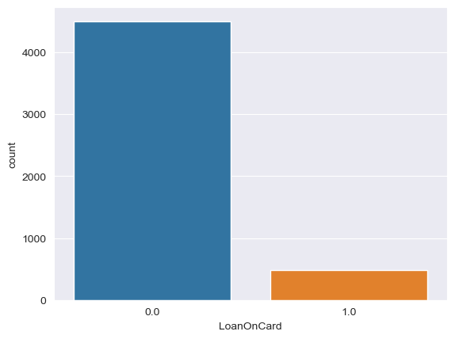

```python
sns.countplot(x='LoanOnCard', data=df)
```

Observations

1. The data seems to be imbalsnced as the blue bar shows sround 4000 observtaiosn and ornage one just shows 500
2. Around 90% of people hold loans on card value zeroi.e they have no loan on credit card.

### B. Check the percentage of missing values and impute if required.

```python
df.isnull().sum()
```

```
ID                      0
Age                     0
CustomerSince           0
HighestSpend            0
ZipCode                 0
HiddenScore             0
MonthlyAverageSpend     0
Level                   0
Mortgage                0
Security                0
FixedDepositAccount     0
InternetBanking         0
CreditCard              0
LoanOnCard             20
dtype: int64
```

```python
perc = df.isnull().sum() * 100 / len(df)
miss = pd.DataFrame({'Percentage of missing values': perc})
miss
```

[output not shown]

Observations

1. Excluding LoanOnCard not any of the features have null/missing values.
2. On LoanOnCard missing values percentage is 0.4
3. Dropping the missing value observtaions as tehy are too low

```python
df.dropna(axis=0,inplace=True)
```

```python
df.shape
```

```
(4980, 14)
```

```python
df.head()
```

|  | ID | Age | CustomerSince | HighestSpend | ZipCode | HiddenScore | MonthlyAverageSpend | Level | Mortgage | Security | FixedDepositAccount | InternetBanking | CreditCard | LoanOnCard |
| --- | --- | --- | --- | --- | --- | --- | --- | --- | --- | --- | --- | --- | --- | --- |
| 9 | 10 | 34 | 9 | 180 | 93023 | 1 | 8.9 | 3 | 0 | 0 | 0 | 0 | 0 | 1.0 |
| 10 | 11 | 65 | 39 | 105 | 94710 | 4 | 2.4 | 3 | 0 | 0 | 0 | 0 | 0 | 0.0 |
| 11 | 12 | 29 | 5 | 45 | 90277 | 3 | 0.1 | 2 | 0 | 0 | 0 | 1 | 0 | 0.0 |
| 12 | 13 | 48 | 23 | 114 | 93106 | 2 | 3.8 | 3 | 0 | 1 | 0 | 0 | 0 | 0.0 |
| 13 | 14 | 59 | 32 | 40 | 94920 | 4 | 2.5 | 2 | 0 | 0 | 0 | 1 | 0 | 0.0 |

```python
df.isnull().sum()
```

```
ID                     0
Age                    0
CustomerSince          0
HighestSpend           0
ZipCode                0
HiddenScore            0
MonthlyAverageSpend    0
Level                  0
Mortgage               0
Security               0
FixedDepositAccount    0
InternetBanking        0
CreditCard             0
LoanOnCard             0
dtype: int64
```

### C. Check for unexpected values in each categorical variable and impute with best suitable value.

```python
columns=['HiddenScore','Level','Security','FixedDepositAccount', 'InternetBanking', 'CreditCard', 'LoanOnCard']
for i in columns:
    print('The unique values in the feature ', i)
    print(df[i].value_counts())
    print()
```

```
The unique values in the feature  HiddenScore
1    1466
2    1293
4    1215
3    1006
Name: HiddenScore, dtype: int64

The unique values in the feature  Level
1    2089
3    1496
2    1395
Name: Level, dtype: int64

The unique values in the feature  Security
0    4460
1     520
Name: Security, dtype: int64

The unique values in the feature  FixedDepositAccount
0    4678
1     302
Name: FixedDepositAccount, dtype: int64

The unique values in the feature  InternetBanking
1    2974
0    2006
Name: InternetBanking, dtype: int64

The unique values in the feature  CreditCard
0    3514
1    1466
Name: CreditCard, dtype: int64

The unique values in the feature  LoanOnCard
0.0    4500
1.0     480
Name: LoanOnCard, dtype: int64
```

Observations

1. on iterating through all the features we see that no unexpected values are present in the categorical variables

## 3. Data Preparation and model building

```python
df['LoanOnCard'] = df.LoanOnCard.astype('category')
```

```python
df.dtypes
```

```
ID                        int64
Age                       int64
CustomerSince             int64
HighestSpend              int64
ZipCode                   int64
HiddenScore            category
MonthlyAverageSpend     float64
Level                  category
Mortgage                  int64
Security               category
FixedDepositAccount    category
InternetBanking        category
CreditCard             category
LoanOnCard             category
dtype: object
```

```python
df.describe(include='all').T
```

|  | count | unique | top | freq | mean | std | min | 25% | 50% | 75% | max |
| --- | --- | --- | --- | --- | --- | --- | --- | --- | --- | --- | --- |
| ID | 4980.0 | NaN | NaN | NaN | 2510.345382 | 1438.011129 | 10.0 | 1265.75 | 2510.5 | 3755.250 | 5000.0 |
| Age | 4980.0 | NaN | NaN | NaN | 45.352610 | 11.464212 | 23.0 | 35.00 | 45.0 | 55.000 | 67.0 |
| CustomerSince | 4980.0 | NaN | NaN | NaN | 20.117671 | 11.468716 | -3.0 | 10.00 | 20.0 | 30.000 | 43.0 |
| HighestSpend | 4980.0 | NaN | NaN | NaN | 73.852410 | 46.070090 | 8.0 | 39.00 | 64.0 | 98.000 | 224.0 |
| ZipCode | 4980.0 | NaN | NaN | NaN | 93152.420482 | 2123.660073 | 9307.0 | 91911.00 | 93407.0 | 94608.000 | 96651.0 |
| HiddenScore | 4980.0 | 4.0 | 1.0 | 1466.0 | NaN | NaN | NaN | NaN | NaN | NaN | NaN |
| MonthlyAverageSpend | 4980.0 | NaN | NaN | NaN | 1.939536 | 1.750006 | 0.0 | 0.70 | 1.5 | 2.525 | 10.0 |
| Level | 4980.0 | 3.0 | 1.0 | 2089.0 | NaN | NaN | NaN | NaN | NaN | NaN | NaN |
| Mortgage | 4980.0 | NaN | NaN | NaN | 56.589759 | 101.836758 | 0.0 | 0.00 | 0.0 | 101.000 | 635.0 |
| Security | 4980.0 | 2.0 | 0.0 | 4460.0 | NaN | NaN | NaN | NaN | NaN | NaN | NaN |
| FixedDepositAccount | 4980.0 | 2.0 | 0.0 | 4678.0 | NaN | NaN | NaN | NaN | NaN | NaN | NaN |
| InternetBanking | 4980.0 | 2.0 | 1.0 | 2974.0 | NaN | NaN | NaN | NaN | NaN | NaN | NaN |
| CreditCard | 4980.0 | 2.0 | 0.0 | 3514.0 | NaN | NaN | NaN | NaN | NaN | NaN | NaN |
| LoanOnCard | 4980.0 | 2.0 | 0.0 | 4500.0 | NaN | NaN | NaN | NaN | NaN | NaN | NaN |

### A. Split data into X and Y.

```python
df = df.drop(['ID', 'ZipCode'], axis =1 )
df.head()
```

|  | Age | CustomerSince | HighestSpend | HiddenScore | MonthlyAverageSpend | Level | Mortgage | Security | FixedDepositAccount | InternetBanking | CreditCard | LoanOnCard |
| --- | --- | --- | --- | --- | --- | --- | --- | --- | --- | --- | --- | --- |
| 9 | 34 | 9 | 180 | 1 | 8.9 | 3 | 0 | 0 | 0 | 0 | 0 | 1.0 |
| 10 | 65 | 39 | 105 | 4 | 2.4 | 3 | 0 | 0 | 0 | 0 | 0 | 0.0 |
| 11 | 29 | 5 | 45 | 3 | 0.1 | 2 | 0 | 0 | 0 | 1 | 0 | 0.0 |
| 12 | 48 | 23 | 114 | 2 | 3.8 | 3 | 0 | 1 | 0 | 0 | 0 | 0.0 |
| 13 | 59 | 32 | 40 | 4 | 2.5 | 2 | 0 | 0 | 0 | 1 | 0 | 0.0 |

```python
X=df.drop(columns='LoanOnCard')
y=df['LoanOnCard']
X.head()
```

|  | Age | CustomerSince | HighestSpend | HiddenScore | MonthlyAverageSpend | Level | Mortgage | Security | FixedDepositAccount | InternetBanking | CreditCard |
| --- | --- | --- | --- | --- | --- | --- | --- | --- | --- | --- | --- |
| 9 | 34 | 9 | 180 | 1 | 8.9 | 3 | 0 | 0 | 0 | 0 | 0 |
| 10 | 65 | 39 | 105 | 4 | 2.4 | 3 | 0 | 0 | 0 | 0 | 0 |
| 11 | 29 | 5 | 45 | 3 | 0.1 | 2 | 0 | 0 | 0 | 1 | 0 |
| 12 | 48 | 23 | 114 | 2 | 3.8 | 3 | 0 | 1 | 0 | 0 | 0 |
| 13 | 59 | 32 | 40 | 4 | 2.5 | 2 | 0 | 0 | 0 | 1 | 0 |

```python
X = pd.get_dummies(X, drop_first=True)
X.head()
```

|  | Age | CustomerSince | HighestSpend | MonthlyAverageSpend | Mortgage | HiddenScore_2 | HiddenScore_3 | HiddenScore_4 | Level_2 | Level_3 | Security_1 | FixedDepositAccount_1 | InternetBanking_1 | CreditCard_1 |
| --- | --- | --- | --- | --- | --- | --- | --- | --- | --- | --- | --- | --- | --- | --- |
| 9 | 34 | 9 | 180 | 8.9 | 0 | 0 | 0 | 0 | 0 | 1 | 0 | 0 | 0 | 0 |
| 10 | 65 | 39 | 105 | 2.4 | 0 | 0 | 0 | 1 | 0 | 1 | 0 | 0 | 0 | 0 |
| 11 | 29 | 5 | 45 | 0.1 | 0 | 0 | 1 | 0 | 1 | 0 | 0 | 0 | 1 | 0 |
| 12 | 48 | 23 | 114 | 3.8 | 0 | 1 | 0 | 0 | 0 | 1 | 1 | 0 | 0 | 0 |
| 13 | 59 | 32 | 40 | 2.5 | 0 | 0 | 0 | 1 | 1 | 0 | 0 | 0 | 1 | 0 |

```python
y.value_counts()
```

```
0.0    4500
1.0     480
Name: LoanOnCard, dtype: int64
```

### B. Split data into train and test. Keep 25% data reserved for testing.

```python
X_train, X_test, y_train, y_test = train_test_split(X, y, test_size=0.25, random_state=5)
print(X_train.shape)
print(y_train.shape)
print(X_test.shape)
print(y_test.shape)
```

```
(3735, 14)
(3735,)
(1245, 14)
(1245,)
```

### C. Train a Supervised Learning Classification base model - Logistic Regression.

1. As logistic sigmoid function is not impacted by outliers we dont normalize the data

```python
from sklearn.linear_model import LogisticRegression
from sklearn.svm import SVC
from sklearn.model_selection import GridSearchCV, RandomizedSearchCV
logreg = LogisticRegression(max_iter=2000)
logreg.fit(X_train, y_train.values.ravel())
y_predict = logreg.predict(X_test)
print('Predicted values in y\n', y_predict)
coef_df = pd.DataFrame(logreg.coef_)
coef_df['intercept'] = logreg.intercept_
print('\nCoefficient values\n', coef_df)
logreg_score = logreg.score(X_test, y_test)
print('\nTest Accuracy: ', np.round(logreg_score,2))
logreg_score = logreg.score(X_train, y_train)
print('\nTrain Accuracy: ', np.round(logreg_score,2))
```

```
Predicted values in y
 [0. 0. 0. ... 0. 1. 0.]

Coefficient values
           0         1         2         3         4         5         6  \
0 -0.057237  0.061739  0.059808  0.185059  0.000336 -0.263006  1.836799

         7         8         9      10        11        12        13  \
0  1.30394  3.569899  3.749943 -0.4743  3.017897 -0.666461 -0.819719

   intercept
0 -10.653317

Test Accuracy:  0.95

Train Accuracy:  0.96
```

### D. Print evaluation metrics for the model and clearly share insights.

```python
cm=metrics.confusion_matrix(y_test, y_predict, labels=[1, 0])
cm
```

```
array([[  82,   52],
       [  14, 1097]], dtype=int64)
```

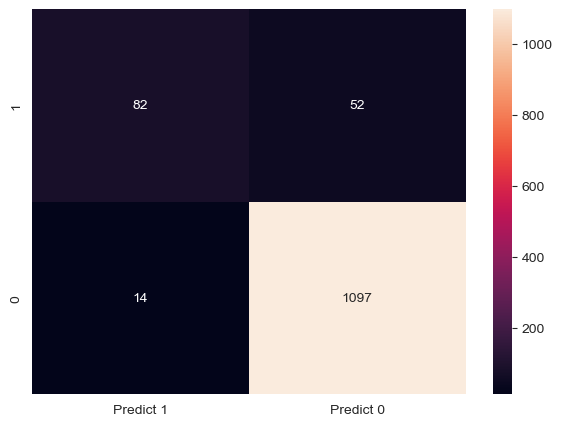

```python
df_cm = pd.DataFrame(cm,
                index = [i for i in ["1","0"]],
                columns = [i for i in ["Predict 1","Predict 0"]])
plt.figure(figsize = (7,5))
sns.heatmap(df_cm, annot=True, fmt='g')
```

```python
print("\nclassification  Matrix:\n", classification_report(y_test,y_predict))
```

```
classification  Matrix:
               precision    recall  f1-score   support

         0.0       0.95      0.99      0.97      1111
         1.0       0.85      0.61      0.71       134

    accuracy                           0.95      1245
   macro avg       0.90      0.80      0.84      1245
weighted avg       0.94      0.95      0.94      1245
```

Observations:

From the above The confusion matrix we infer that

1. True Positives (TP): The number of correctly predicted 1 values are 82
2. True Negatives (TN): The number of correctly predicted 2 values are 1097
3. False Positives (FP): The number of Type I errors are 14
4. False Negatives (FN): The number of Type II error are52

The accuracy is much higher with

1. Testing data Accuracy = 95 %
2. Training data Accuracy = 96 %

Recall tells that only 61% LoanOnCard = 1 is predicted correctly from actual values. it as a weaker model for predicting LoanOnCard = 1 in comparison to LoanOnCard = 0 We need more amount/sample of class 1 to train the model, but it is less.

### E. Balance the data using the right balancing technique.

### i. Check distribution of the target variable

### ii. Say output is class A : 20% and class B : 80%

```python
n_true = len(df.loc[df['LoanOnCard'] == 1])
n_false = len(df.loc[df['LoanOnCard'] == 0])
print("Number of true cases: {0} ({1:2.2f}%)".format(n_true, (n_true / (n_true + n_false)) * 100 ))
print("Number of false cases: {0} ({1:2.2f}%)".format(n_false, (n_false / (n_true + n_false)) * 100))
```

```
Number of true cases: 480 (9.64%)
Number of false cases: 4500 (90.36%)
```

Observations

1. Around 90.36% of the people in the current dataset are for LoadOnCard = 0
2. Only 9.64% of teh people in the current dataset are for LoadOnCard = 1
3. Se dont see taht data is balanced/normally distributed.so we need to balance/normalise it

### iii. Here you need to balance the target variable as 50:50.

### iv. Try appropriate method to achieve the same.

Using a sampling technique called SMOTE to balance the target variable on training data only

```python
from imblearn.over_sampling import SMOTE
smt = SMOTE(random_state=42)
X_train_smt, y_train_smt = smt.fit_resample(X_train, y_train)
print('Before sampling:', y_train.value_counts())
print('\n After sampling:', y_train_smt.value_counts())
```

```
Before sampling: 0.0    3389
1.0     346
Name: LoanOnCard, dtype: int64

 After sampling: 0.0    3389
1.0    3389
Name: LoanOnCard, dtype: int64
```

### F. Again train the same previous model on balanced data.

```python
logreg.fit(X_train_smt, y_train_smt.values.ravel())
y_predict = logreg.predict(X_test)
print('Predicted Values in y\n', y_predict)
coef_df = pd.DataFrame(logreg.coef_)
coef_df['intercept'] = logreg.intercept_
print('\nCoefficient values\n',coef_df)
```

```
Predicted Values in y
 [0. 0. 0. ... 0. 0. 0.]

Coefficient values
           0         1       2         3         4        5         6  \
0  0.052395 -0.053458  0.0499  0.262984 -0.000032 -2.87305 -0.544145

          7        8         9        10        11        12        13  \
0 -0.804134  0.52218  0.660203 -2.178239  3.331493 -1.309445 -2.156637

   intercept
0  -6.136359
```

### G. Print evaluation metrics and clearly share differences observed.

[output not shown]

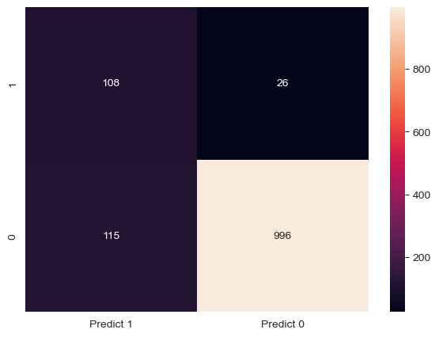

```python
logreg_score = logreg.score(X_test, y_test)
print('Test Accuracy: ', np.round(logreg_score,2))
logreg_score = logreg.score(X_train_smt, y_train_smt)
print('Train Accuracy: ', np.round(logreg_score,2))
cm=metrics.confusion_matrix(y_test, y_predict, labels=[1, 0])

df_cm = pd.DataFrame(cm, index = [i for i in ["1","0"]],
                  columns = [i for i in ["Predict 1","Predict 0"]])
plt.figure(figsize = (7,5))
sns.heatmap(df_cm, annot=True, fmt='g')
```

```python
print("\nclassification  Report:\n", classification_report(y_test,y_predict))
```

```
classification  Report:
               precision    recall  f1-score   support

         0.0       0.97      0.90      0.93      1111
         1.0       0.48      0.81      0.61       134

    accuracy                           0.89      1245
   macro avg       0.73      0.85      0.77      1245
weighted avg       0.92      0.89      0.90      1245
```

Observations

## 4. Performance Improvement

Some inital steps:

1. To build eihter SVM or KNN we must normalise the data
2. We consume evenly distributed sampling data for model building
3. Both X_train_smt & X_test must be normalised

```python
X_train_smt.dtypes
```

```
Age                        int64
CustomerSince              int64
HighestSpend               int64
MonthlyAverageSpend      float64
Mortgage                   int64
HiddenScore_2              uint8
HiddenScore_3              uint8
HiddenScore_4              uint8
Level_2                    uint8
Level_3                    uint8
Security_1                 uint8
FixedDepositAccount_1      uint8
InternetBanking_1          uint8
CreditCard_1               uint8
dtype: object
```

```python
columns = ['Age', 'CustomerSince', 'HighestSpend', 'MonthlyAverageSpend', 'Mortgage']
for i in columns:
    X_test[i] = stats.zscore(X_test[i])
    X_train_smt[i] = stats.zscore(X_train_smt[i])
X_train_smt.head()
```

|  | Age | CustomerSince | HighestSpend | MonthlyAverageSpend | Mortgage | HiddenScore_2 | HiddenScore_3 | HiddenScore_4 | Level_2 | Level_3 | Security_1 | FixedDepositAccount_1 | InternetBanking_1 | CreditCard_1 |
| --- | --- | --- | --- | --- | --- | --- | --- | --- | --- | --- | --- | --- | --- | --- |
| 0 | 1.712264 | 1.727462 | -1.570288 | -1.161098 | -0.558397 | 0 | 1 | 0 | 0 | 0 | 1 | 1 | 1 | 1 |
| 1 | -0.621429 | -0.600622 | 0.249355 | 0.251694 | -0.558397 | 0 | 0 | 0 | 1 | 0 | 0 | 1 | 1 | 1 |
| 2 | -1.159974 | -1.316955 | -1.213863 | -0.908814 | 0.304249 | 1 | 0 | 0 | 1 | 0 | 1 | 0 | 1 | 0 |
| 3 | -0.082885 | -0.152913 | 0.324392 | 1.563573 | -0.558397 | 0 | 1 | 0 | 0 | 0 | 0 | 1 | 1 | 1 |
| 4 | -1.698518 | -1.675122 | -0.069551 | -0.454702 | -0.558397 | 0 | 0 | 0 | 0 | 0 | 0 | 0 | 0 | 0 |

```python
X_test.head()
```

|  | Age | CustomerSince | HighestSpend | MonthlyAverageSpend | Mortgage | HiddenScore_2 | HiddenScore_3 | HiddenScore_4 | Level_2 | Level_3 | Security_1 | FixedDepositAccount_1 | InternetBanking_1 | CreditCard_1 |
| --- | --- | --- | --- | --- | --- | --- | --- | --- | --- | --- | --- | --- | --- | --- |
| 2080 | 1.736581 | 1.768183 | -0.118702 | -1.038028 | -0.56698 | 0 | 0 | 1 | 1 | 0 | 0 | 0 | 1 | 0 |
| 1607 | 0.847802 | 0.785540 | -1.156999 | -0.704502 | -0.56698 | 0 | 0 | 1 | 0 | 1 | 0 | 0 | 0 | 0 |
| 609 | -0.752000 | -0.822421 | -1.092105 | -0.259802 | -0.56698 | 0 | 0 | 1 | 0 | 1 | 0 | 0 | 0 | 0 |
| 1059 | -1.551901 | -1.626401 | -1.373310 | -1.038028 | -0.56698 | 0 | 0 | 0 | 1 | 0 | 0 | 0 | 1 | 1 |
| 4875 | 1.381069 | 1.410858 | -0.443170 | -0.259802 | -0.56698 | 0 | 1 | 0 | 0 | 0 | 0 | 0 | 1 | 0 |

## SVM Model

```python
svc_model = SVC()
svc_model.fit(X_train_smt, y_train_smt)
prediction = svc_model.predict(X_test)
print(f"Training set Score: {svc_model.score(X_train_smt, y_train_smt)}")
print(f"Testing set Score: {svc_model.score(X_test, y_test)}")
```

```
Training set Score: 0.9507229271171437
Testing set Score: 0.7606425702811245
```

```python
print("Confusion Matrix:\n", confusion_matrix(prediction,y_test))
```

```
Confusion Matrix:
 [[818   5]
 [293 129]]
```

```python
print(classification_report(prediction, y_test))
```

```
              precision    recall  f1-score   support

         0.0       0.74      0.99      0.85       823
         1.0       0.96      0.31      0.46       422

    accuracy                           0.76      1245
   macro avg       0.85      0.65      0.65      1245
weighted avg       0.81      0.76      0.72      1245
```

```python
pg = {"C":[0.01,0.1,1,10, 100], "kernel":["rbf","linear"], "gamma":[0.001, 0.01, 0.1,1, 10, 100]}
svc_mod = SVC()
gs = GridSearchCV(svc_mod, param_grid=pg)
gs.fit(X_train_smt, y_train_smt)
```

```
GridSearchCV(estimator=SVC(),
             param_grid={'C': [0.01, 0.1, 1, 10, 100],
                         'gamma': [0.001, 0.01, 0.1, 1, 10, 100],
                         'kernel': ['rbf', 'linear']})
```

```python
gs.best_estimator_
```

```
SVC(C=100, gamma=1)
```

```python
gs.best_params_
```

```
{'C': 100, 'gamma': 1, 'kernel': 'rbf'}
```

```python
gs.best_score_
```

```
0.9552990671499636
```

```python
gs.score(X_test, y_test)
```

```
0.7927710843373494
```

```python
prediction = gs.predict(X_test)
print("Confusion Matrix:\n",confusion_matrix(prediction,y_test),
      "\nClassification Report:\n", classification_report(prediction, y_test))
```

```
Confusion Matrix:
 [[887  34]
 [224 100]]
Classification Report:
               precision    recall  f1-score   support

         0.0       0.80      0.96      0.87       921
         1.0       0.75      0.31      0.44       324

    accuracy                           0.79      1245
   macro avg       0.77      0.64      0.65      1245
weighted avg       0.78      0.79      0.76      1245
```

Observations:

## KNN Model

```python
knn = KNeighborsClassifier()
knn.fit(X_train_smt, y_train_smt)
y_pred = knn.predict(X_test)
print('Accuracy -', accuracy_score(y_test, y_pred) )
print('Recall -', recall_score(y_test, y_pred, average= 'weighted'))
print('Precision -', precision_score(y_test, y_pred, average= 'weighted'))
pred = knn.predict(X_test)
print("Score -", knn.score(X_test, y_test))
```

```
Accuracy - 0.7775100401606426
Recall - 0.7775100401606426
Precision - 0.9138188212999084
Score - 0.7775100401606426
```

```python
print("classification  Matrix:\n", classification_report(y_test,pred))
```

```
classification  Matrix:
               precision    recall  f1-score   support

         0.0       0.99      0.76      0.86      1111
         1.0       0.32      0.91      0.47       134

    accuracy                           0.78      1245
   macro avg       0.65      0.84      0.66      1245
weighted avg       0.91      0.78      0.82      1245
```

```python
l1 = list(range(1,70))
neighbors = list(filter(lambda x: x % 2 != 0, l1))
```

```python
ac_scores = []
for k in neighbors:
    knn = KNeighborsClassifier(n_neighbors=k)
    knn.fit(X_train_smt, y_train_smt)
    y_pred = knn.predict(X_test)
    scores = accuracy_score(y_test, y_pred)
    ac_scores.append(scores)
MSE = [1 - x for x in ac_scores]
optimal_k = neighbors[MSE.index(min(MSE))]
print("The optimal number of neighbours is %d" % optimal_k)
```

```
The optimal number of neighbours is 1
```

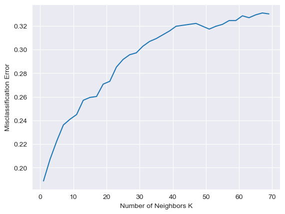

```python
plt.plot(neighbors, MSE)
plt.xlabel('Number of Neighbors K')
plt.ylabel('Misclassification Error')
plt.show()
```

**Observations**:

- Plot shows K=1 to be an optimal number, just relying on one neighbour datapoint would lead to over fitting in the data so we choose the next optimal K value as 3

```python
knn = KNeighborsClassifier(n_neighbors= 3 , weights = 'distance' )
knn.fit(X_train_smt, y_train_smt)
y_pred = knn.predict(X_test)
print('Accuracy on Test data:', accuracy_score(y_test, y_pred) )
print('Recall on Test data:', recall_score(y_test, y_pred, average= 'weighted') )
print('Precision on Test data:', precision_score(y_test, y_pred, average= 'weighted'))
pred = knn.predict(X_test)
knn.score(X_test, y_test)
print("Score -", knn.score(X_test, y_test))
print("classification  Matrix:\n", classification_report(y_test,pred))
```

```
Accuracy on Test data: 0.7927710843373494
Recall on Test data: 0.7927710843373494
Precision on Test data: 0.9158410350539035
Score - 0.7927710843373494
classification  Matrix:
               precision    recall  f1-score   support

         0.0       0.99      0.78      0.87      1111
         1.0       0.33      0.91      0.49       134

    accuracy                           0.79      1245
   macro avg       0.66      0.84      0.68      1245
weighted avg       0.92      0.79      0.83      1245
```

Observations

1. Accuracy for testing data increased from 77.75 to 79.27
2. Precision shows increased values from 91.38 to 91.58